# Two-step matching and interpolation without kpoints

## Introduction

This vignette describes a workflow that covers site selection, matching, and interpolation for a case where **subset cells** were not determined using the `kpoints` function. This workflow is appropriate when the goals is to interpolate simulation results from **subset cells** to create high-resolution, continuous maps of the study area. Here, we illustrate the workflow using an example for the state of Wyoming, where **subset cells** were generated using a regular 10 x 10 km grid (see Bradford et al. (2019) for details). The code chunks in this document are meant to be run sequentially. Data relevant to this example are contained within the `rMultivariateMatching` package. The site-selection and interpolation methods are described in:

> Renne, R. R., Schlaepfer, D. R., Palmquist, K. A., Lauenroth, W. K., & Bradford, J. B. In preparation. Estimating complex ecological variables at high resolution in heterogeneous terrain using a multivariate matching algorithm.

### Examples of the interpolation methods in print

In the interpolation example in *Renne et al.*, our goal was to generate high-resolution, 30-arcsecond maps of SOILWAT2 simulation output with low spatial resolution (10 x 10 km). SOILWAT2 is a process-based ecohydrological simulation model (Schlaepfer et al., 2012; Schlaepfer & Andrews, 2018; Schlaepfer & Murphy, 2018). The two-step matching method described in *Renne et al.* was devised to interpolate simulation output for a series of studies investigating the potential impacts of climate change on ecohydological variables in western North American drylands. Interpolated datasets from these studies will soon be available from the US Geological Survey Sciencebase:

> Citations to follow when available.

## Overview and definitions

In this vignette, we assume that we have already determined appropriate **matching variables** and **matching criteria** and run simulations for the **subset cells**. Note that this workflow is distinct from a workflow where the simulated sites (**subset cells**) are selected using `kpoints`. A workflow for that scenario can be found in the “Matching and interpolation with kpoints” vignette. Furthermore, the example here is derived from the interpolation example in *Renne et al.* that used a two-step matching process to fit the experimental design described in Bradford et al., (2019). This workflow is somewhat specialized to that experimental design. However, a workflow that illustrates single-step matching and interpolation using **subset cells** that are not derived from the `kpoints` function can be found in the “Matching and interpolation without kpoints” vignette.

The functions in the `rMultivariateMatching` package measure similarity between sites as the Euclidean distance of standardized (i.e., weighted) **matching variables**. Each variable is standardized by dividing it by the maximum amount of difference that would still allow two sites to be considered analogous for that variable. These maximum differences are called the **matching criteria** for each variable. For example, if two sites could be reasonably considered analogous as long as they were within 50 mm of each other for mean annual precipitation (MAP), the matching criteria for MAP could be set to 50 mm. Distances are calculated within the `rMultivariateMatching` function using the `distances` package (Savje 2019).

### Definitions

- **subset cells** A subset of sites (selected using `kpoints` or determined from some other method) for simulation. Sites are defined geographically as the centroid of the raster cells that they represent.
- **target cells** All cells across a study area.
- **matching variables** A set of variables relevant to the ecosystem and simulation model that are used to determine similarity between sites. Matching variables must be available as rasters covering the entire study area.
- **matching criteria** Maximum allowable differences between Target and matched Subset cells for each matching variable such that sites can be considered analogous.
- **kpoints** Site selection algorithm that uses multivariate clustering based on the unsupervised classification scheme, *k-means* (MacQueen 1967), to find groups of analogous sites across a study area.

The figure below illustrates an overview of the site selection and interpolation methods and key terminology. First, a set of **matching variables** are selected and standardized using user-defined **matching criteria**. Next, the `kpoints` algorithm is used to determine an optimal set of *k* **subset cells** for use in field sampling or simulation. All **target cells** are matched to one of the **subset cells** (matches are denoted by color in central panel). Finally, point results (e.g., simulation output) for the **subset cells** are interpolated across the study area using multivariate matching to produce continuous, high-resolution maps of output, such as plant functional type biomass or ecohydrological variables.

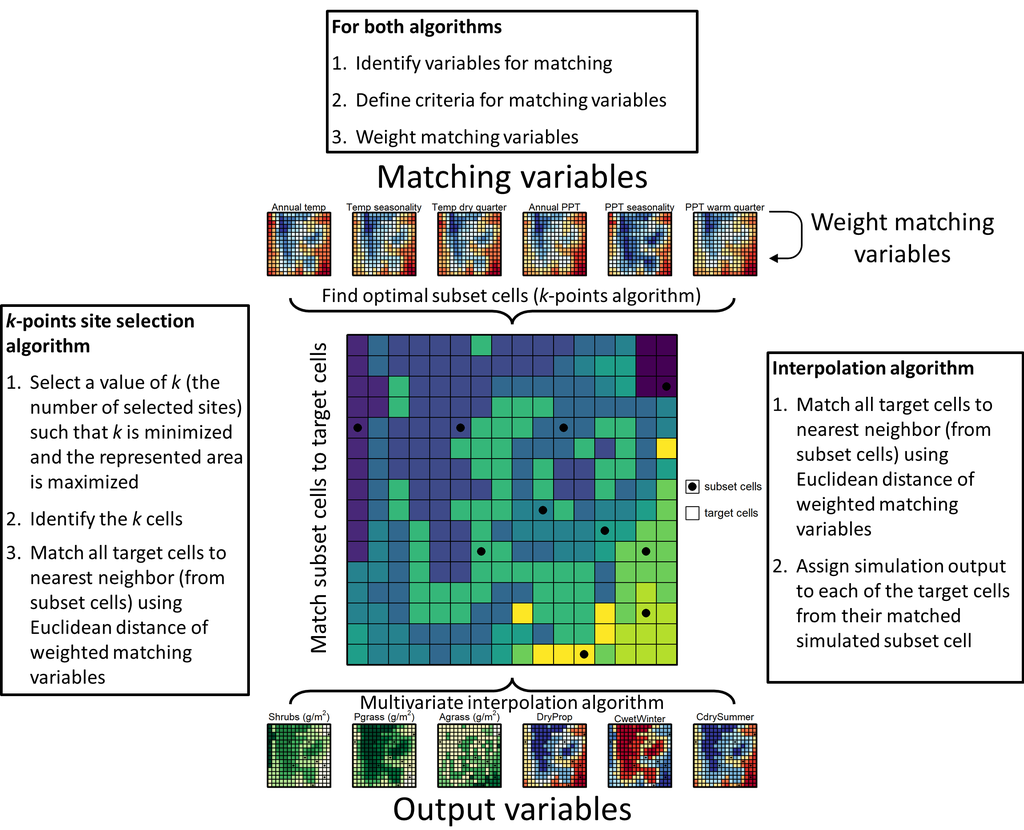

```r
library(rMultivariateMatching)
```

## Prepare inputs

The first step is to use the `makeInputdata` function to convert a `rasterStack` (see the `raster` package (Hijmans 2021) for details) of matching (and other) variables into the correct format to be used in subsequent functions.

```r
# Load targetcells data for Target Cells
data(targetcells)
# Create data frame of potential matching variables for Target Cells
allvars <- makeInputdata(targetcells)
```

## Determine matching criteria

The next step is to determine **matching criteria**, that is, the maximum allowable difference for each **matching variable** between **target** and matched **subset cells**, such that the cells can be considered environmentally analogous. You may have some idea of what **matching criteria** should be based on your knowledge of the system and processes in question, but it can be useful to evaluate how the proportion of the study area that is represented by the **subset cells** changes with different **matching criteria** using the `choose_criteria` function.

```r
# Restrict data to matching variables of interest
matchingvars <- allvars[,c("cellnumbers","x","y","bioclim_01","bioclim_04",
                           "bioclim_09","bioclim_12","bioclim_15","bioclim_18")]

# Create list of matching criteria to choose:
# Look at 2.5%, 5%, & 10% of range and standard deviation for each variable
range2.5pct <- apply(matchingvars[,4:ncol(matchingvars)],2,
                     function(x){(max(x)-min(x))*0.025})
range5pct <- apply(matchingvars[,4:ncol(matchingvars)],2,
                   function(x){(max(x)-min(x))*0.05})
range10pct <- apply(matchingvars[,4:ncol(matchingvars)],2,
                    function(x){(max(x)-min(x))*0.1})
stddev <- apply(matchingvars[,4:ncol(matchingvars)],2,sd)

# Create criteria_list
criteria_list <- list(range2.5pct, range5pct, range10pct, stddev)
```

#### Table displaying the criteria list

| bioclim_01 | bioclim_04 | bioclim_09 | bioclim_12 | bioclim_15 | bioclim_18 |
| --- | --- | --- | --- | --- | --- |
| 0.36 | 10.62 | 0.82 | 32.97 | 1.36 | 4.61 |
| 0.73 | 21.23 | 1.64 | 65.93 | 2.72 | 9.21 |
| 1.45 | 42.47 | 3.29 | 131.86 | 5.44 | 18.42 |
| 2.49 | 60.37 | 7.41 | 170.74 | 13.53 | 34.27 |

Importantly, the `subsetcells` dataset that is included in the `rMultivariateMatching` package is a subset of sites that were simulated in Bradford et al. (2019). The experimental design of that study selected sites using a 10 x 10 km grid across western North American drylands. For each site, they simulated ecohydrological conditions for five different soil types. Thus, we devised a two-step matching method to fit this experimental design. This vignette demonstrates matching and interpolation using this two-step matching process. However, because the first step of matching only uses climate variables, we will start by limiting the `subsetcells` dataset to climatic **matching variables** as shown above.

```r
# Bring in Subset cell data
data(subsetcells)

# Remove duplicates (representing cells with same climate but different soils--
# we want to match on climate only)
subsetcells <- subsetcells[seq(1,10630, by = 5),]

# Pull out matching variables only, with site_id that identifies unique climate
subsetcells <- subsetcells[,c("site_id","X_WGS84","Y_WGS84","bioclim_01",
                              "bioclim_04","bioclim_09","bioclim_12",
                              "bioclim_15","bioclim_18")]

# Ensure that site_id will be values unique to subsetcells
subsetcells$site_id <- paste0("00",subsetcells$site_id)
```

### Explanation of `choose_criteria` arguments

Please also refer to the `choose_criteria` documentation.

- `matchingvars` A data frame representing all **target cells** used to calculate similarity between **subset** and **target cells**. This data frame can be created using the `makeInputdata` function.
- `criteria_list` A list of vectors of **matching criteria** to be tested.
- `raster_template` This is one of the rasters used to define the **target cells** and it is used as a template to determine the area represented by each iteration and by the solution for each of the `n_starts`. This argument is fundamental to the `kpoints` function because `kpoints` is designed to optimize based on represented area.
- `subset_in_target` A boolean indicating if the **subset cells** are taken from within the **target cells**. This is `FALSE` in our example.
- `plot_coverage` A boolean indicating if the proportion of the study area represented by each vector of **matching criteria** in the `criteria_list` should be displayed in a bar plot. (Set to `TRUE` in this example).
- `subsetcells` Passed to `multivarmatch` function if `subset_in_target` is `FALSE` (as in this example). This should be a data frame of **subset cells** with column names corresponding exactly to those in `matchingvars` and row names should be unique identifiers.
- `matchingvars_id` Name of the column in `matchingvars`that provides the unique identifiers for **target cells**.
- `subsetcells_id` Name of the column in `subsetcells`that provides the unique identifiers for **subset cells**. Note that these unique identifiers should be numbers, but they may be classified as characters. In particular, if there are repeats among the`matchingvars_id`s and the `subsetcells_id`s, you can paste “00” before the `subsetcells_id`s to ensure they are unique from the `matchingvars_id`s (as we did in the previous code block).
- `matching_distance` Gives the maximum allowable matching quality value (weighted Euclidean distance) between **target** and **subset cells**, when `subset_in_target` is `FALSE`. Default value is 1 so that output will be comparable to output from `choose_criteria` when `subset_in_target` is `TRUE`.

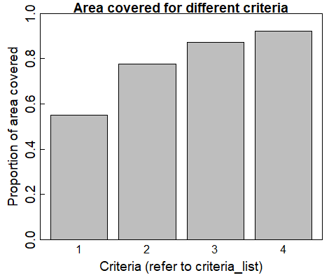

```r
# Run choose_criteria function to evaluate different matching criteria
coverage <- choose_criteria(matchingvars = matchingvars,
                            criteria_list = criteria_list,
                            plot_coverage = TRUE,
                            raster_template = targetcells[[1]],
                            subset_in_target = FALSE,
                            subsetcells = subsetcells,
                            matchingvars_id = "cellnumbers",
                            subsetcells_id = "site_id",
                            matching_distance = 1)
```

### Explanation of `choose_criteria` outputs

The output from the `choose_criteria` function is a named list where the first item (‘totalarea’) reports the total area in $km^2$ of the **target cells** and the second item (‘solution_areas’) reports the area represented (Euclidean distance of weighted **matching variables** $\le 1$ between **target** and matched **subset cells**) for each set of **matching criteria**.

## Perform matching

The two-step matching method described in *Renne et al.* uses the experimental design presented in Bradford et al. (2019) to match low spatial resolution simulated sites (**subset cells**) to high-resolution **target cells**. Each low resolution **subset cell** was simulated with five different soil types, so we have five different sets of output results for each individual site. To achieve matching between these sites and **target cells** we first matched using climate variables, then we found the best match for each **target cell** from the five available soil types for the **subset cell** it was matched to using climate variables.

### First, match on climate variables

Use the `multivarmatch` function to perform multivariate matching. This function will match every **target cell** to one of the **subset cells**.

### Explanation of `multivarmatch` arguments

Please also refer to the `multivarmatch` documentation.

- `matchingvars` A data frame representing all **target cells**. This data frame can be created using the `makeInputdata` function.
- `subsetcells` A data frame of **subset cells** with column names corresponding exactly to those in `matchingvars`. Rownames should be unique identifiers (unique means no repeats among all row names in `targetcells` and `matchingvars`.
- `criteria` A vector of **matching criteria** that correspond to the **matching variables**. Matching criteria represent the maximum difference allowed for each variable between matched **target** and **subset cells**.
- `matchingvars_id` The name of the column that contains the unique identifiers for each **target cell**. If `matchingvars` is derived from the `makeInputData`, this will be “cellnumbers”.
- `subsetcells_id` The name of the column that contains the unique identifiers for each **subset cell**. Note that these unique identifiers should be numbers, but they may be classified as characters. In particular, if there are repeats among the`matchingvars_id`s and the `subsetcells_id`s, you can paste “00” before the `subsetcells_id`s to ensure they are unique from the `matchingvars_id`s (as we did in the previous code block).
- `addpoints` A boolean indicating whether the **subset cells** should be added to the map of matching quality.
- `raster_template` This is one of the rasters used to define the **target cells** and it is used as a template for creating a raster of matching quality.
- `subset_in_target` A boolean indicating if the **subset cells** are taken from within the **target cells**.

**Note:** the function below does not specify several additional arguments that are left as default values. These include:

- `saveraster` A boolean indicating if a raster of matching quality should be saved to file. (Defaults to `FALSE`).
- `plotraster` A boolean indicating if a raster of matching quality should be plotted. (Defaults to `TRUE`).
- `filepath` A destination for a raster of matching quality in the case where `saveraster` = `TRUE`. (Defaults to working directory).
- `overwrite` A boolean indicating if the `raster::writeRaster` function is allowed to overwrite existing files. (Defaults to `FALSE`).

```r
# Create vector of matching criteria
criteria1 <- c(0.7,42,3.3,66,5.4,18.4)

# Find matches and calculate matching quality
quals <- multivarmatch(matchingvars, subsetcells, criteria = criteria1,
                       matchingvars_id = "cellnumbers",
                       subsetcells_id = "site_id",
                       raster_template = targetcells[[1]],
                       subset_in_target = FALSE, addpoints = FALSE)
```

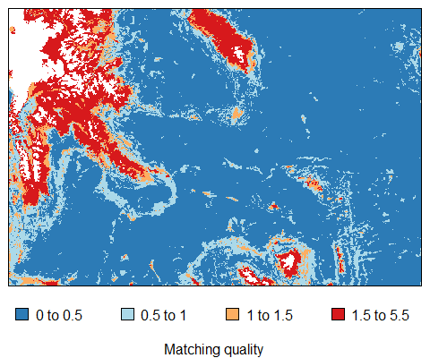

### Explanation of `multivarmatch` outputs

The output from the `multivarmatch` function is a data frame of **target cells** with coordinates (‘x’,‘y’), cellnumber of each **target cell** (‘target_cell’), unique id of the matched **subset cell** (‘subset_cell’), and matching quality (‘matching_quality’). The function will save a raster of matching quality if `saveraster` is `TRUE` and plot a map of matching quality if `plotraster` is `TRUE`.

### Second, match on soil variables

First, we need to bring in soils data for the **subset** and **target cells**. The five soil types used for the **subset cells** include site-specific soils and four set soil types, as shown in the following table.

| treatment | soil type | Sand (%) | Clay (%) | Silt (%) |
| --- | --- | --- | --- | --- |
| 1 | site-specific | variable | variable | variable |
| 2 | silt loam | 30 | 18 | 52 |
| 3 | clay loam | 27 | 35 | 38 |
| 4 | sandy loam | 66 | 9 | 25 |
| 5 | silt loam | 16 | 9 | 75 |

The `secondaryMatching` function matches first on a `reference_treatment` and then compares that match to a set of `other_treatments`. Note that in a case where the same set of treatments were applied to all simulated sites and there is no ‘site-specific’ treatment, `secondaryMatching` will still work if one of the set treatments is designated as the `reference_treatment`

In our case, the `reference_treatment` is the site-specific soil type, designated by ‘.1’ appended onto the `site_id`. The other soil types (`other_treatments`) are designated similarly. An example of the five different soil types and their respective `site_ids` are shown in the following table.

#### Soil types used in simulation

| treatment | site_ids | Sand (%) | Clay (%) |
| --- | --- | --- | --- |
| 1 | 24072.1 | 49.1 | 22.85 |
| 2 | 24072.2 | 30 | 18 |
| 3 | 24072.3 | 27 | 35 |
| 4 | 24072.4 | 66 | 9 |
| 5 | 24072.5 | 16 | 9 |

```r
# Subset to include only secondaryvars
secondaryvars <- allvars[,c("cellnumbers","x","y","sand","clay")]

# Bring in secondary id variable from subsetcells
data(subsetcells)

# Remove duplicates (keeping only site-specific soils with site_ids ending
# in ".1").
subsetcells <- subsetcells[!duplicated(subsetcells$site_id),]

# Pull out matching variables only, with site_id that identifies unique climate
subsetcells <- subsetcells[,c("site_id","X_WGS84","Y_WGS84",
                              "sand","clay"),]

# Convert sand and clay to percentage from fraction
subsetcells$sand <- subsetcells$sand*100
subsetcells$clay <- subsetcells$clay*100

# Make sure subsetcell ids are unique
subsetcells$site_id <- paste0("00",subsetcells$site_id)
```

The `secondaryMatching` function requires `other_treatments` as a data frame where rownames are the numbers designating each treatment type and the columns correspond to the secondary matching variables, in the same order as they appear in `matchingvars` (sand and clay in our case).

Again, you will need to select **matching criteria** for the second matching step. You may have some idea of what these should be and you can experiment some by trying different sets of criteria to see what works best. Note that the `choose_criteria` function does not currently work with `secondaryMatching`, so any experimentation must be done manually (e.g., loop through different sets of criteria and compare coverage). Below, we have set **matching criteria** to 10% of the range of sand and clay among the **target cells**.

### Explanation of `secondaryMatching` arguments

Please also refer to the `secondaryMatching` documentation.

- `secondaryvars` A data frame generated using `makeInputdata` or a subset of such a data frame, where the data columns correspond to a set of secondary **matching variables**. These data represent **target cells**.
- `matches` A data frame output from the `multivarmatch` function.
- `subsetcells` A data frame with columns that correspond to those in `secondaryvars`, but represent only one of the treatments (`reference_treatment`). This function is designed to handle an experimental design in which there is a “reference” treatment (which can be either set for all sites or site-specific) and a series of “other” treatments that are the same across all **subset cells**.
- `subsetcells_id` The name of the column that contains the unique identifiers for each **subset cell**. Note that these unique identifiers should be numbers, but they may be classified as characters. In particular, if there are repeats among the`matchingvars_id`s and the `subsetcells_id`s, you can paste “00” before the `subsetcells_id`s to ensure they are unique from the `matchingvars_id`s.
- `subset_in_target` A boolean indicating if the **subset cells** are taken from within the **target cells**. Currently there is only functionality for `FALSE` in this function.
- `criteria` A vector of **matching criteria** that correspond to the secondary **matching variables**. Matching criteria represent the maximum difference allowed for each variable between matched **target** and **subset cells**.
- `raster_template` This is one of the rasters used to define the **target cells** and it is used as a template for creating a raster of matching quality.
- `reference_treatment` Character, but should be composed only of numbers. Designates the reference treatment identifier that will be pasted onto the `subsetcells_id` as a decimal to generate unique identifiers for each treatment. The combination of the `subsetcells_id` and `reference_treatment` should be able to be converted to numeric. For example, if `subsetcells_id`s are of the form 10001 and the `reference_treatment` is ‘1’, the resulting id would be 10001.1. Default value is ‘1’.
- `other_treatments` A data frame containing the secondary variables for “other” treatments that are the same across all **subset cells** (e.g., a set of soil types that are simulated for each site in our example). The columns should correspond to the `secondarvars` and the rownames will designate the treatment identifiers that will be pasted onto the `subsetcells_id` to generate unique identifiers for each treatment. For example, see our table of treatment types.

**Note:** the function below does not specify several additional arguments that are left as default values. These include:

- `saveraster` A boolean indicating if a raster of matching quality should be saved to file. (Defaults to `FALSE`).
- `plotraster` A boolean indicating if a raster of matching quality should be plotted. (Defaults to `TRUE`).
- `filepath` A destination for a raster of matching quality in the case where `saveraster` = `TRUE`. (Defaults to working directory).
- `overwrite` A boolean indicating if the `raster::writeRaster` function is allowed to overwrite existing files. (Defaults to `FALSE`).

```r
# Bring in "other" treatments
data(setsoiltypes)
other_treatments = setsoiltypes

# Calculate criteria
criteria2 = c((max(secondaryvars$sand,na.rm = T)-
                 min(secondaryvars$sand,na.rm = T))/10,
             (max(secondaryvars$clay,na.rm = T)-
                min(secondaryvars$clay,na.rm = T))/10)

# Run secondary matching on soils data
quals2 <- secondaryMatching(secondaryvars = secondaryvars, matches = quals,
                            subsetcells=subsetcells,subsetcells_id = "site_id",
                            subset_in_target = FALSE, criteria = criteria2,
                            raster_template = targetcells[[1]],
                            reference_treatment = "1",
                            other_treatments = other_treatments)
```

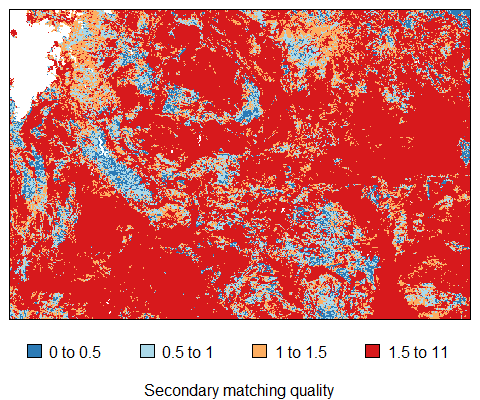

### Explanation of `secondaryMatching` outputs

The output from the `secondaryMatching` function includes output from `multivarmatch` plus columns that provide the unique id of the matched **subset cell** with treatment added as a decimal (‘subset_cell_seconday’), and matching quality of the secondary variables (‘matching_quality_secondary’). The function will save a raster of matching quality if `saveraster` is `TRUE` and plot a map of matching quality if `plotraster` is `TRUE`.

## Evaluate matching

Now that we have completed matching, we should evaluate the success of matching. In *Renne et al.*, we suggest four methods of evaluating matching.

1. Calculate matching quality (weighted Euclidean distance between **target** and matched **subset cells**)
2. Calculate the standard deviation of differences between **target** and matched **subset cells** for a set of variables relevant to the project
3. Calculate geographic distances between matched cells
4. Leave-one-out cross-validation

### 1. Calculate matching quality

In addition to identifying the matching **subset cell** for each **target cell**, the `multivarmatch` and `seondaryMatching` functions also calculate the weighted Euclidean distance between matched cells for the first and second set of **matching variables**, which can be interpreted as a continuous variable measuring matching quality. Distances less than or equal to one indicate high-quality matching (**matching criteria** have been met for all variables). Distances greater than one indicate that the difference between these **target cells** and their matched **subset cell** exceeds the **matching criterion** for one or more variables.

Matching quality can be used to exclude **target cells** for which there is insufficient matching, i.e., no simulated site is analogous, and to determine the spatial extent of the represented area. In *Renne et al.*, we used a cut-off of 1.5 as a threshold between high/moderate quality and low quality matching, and excluded sites with matching quality >1.5 from the final interpolated datasets. Importantly, we did not exclude sites that had low quality matching for soils variables (used in the second matching step) because at 30 arcsecond resolution, the **target cells** are likely to include a range of soil types. Thus, results from the soil type of the matched **subset cells** are likely to be relevant to the **target cells**, even if matching of the soil variables is poor.

### 2. Calculate standard deviation of differences between **target** and matched **subset cells**

Matching can also be evaluated by using the `evaluateMatching` function to calculate the standard deviation of differences between **target** and **subset cells** for a set of variables relevant to the project. This provides an estimate of how much variability there is among the **target cells** matched to each **subset cell** and is particularly informative if the variables were not used as part of the matching process.

If the rownames of `allvars` and `matches` (see below for details) do not match, the `evaluateMatching` function will fail. Importantly, the function will remove cases with missing values from the `allvars` and `matches` data frames and if missing values occur for different cases, the function will fail because the rownames of the two data frames will no longer match.

Here we use 19 bioclim variables (six of which were used as **matching variables**) to evaluate matching in the current example (and include soil variables used in matching for reference).

### Explanation of `evaluateMatching` arguments

Please also refer to the `evaluateMatching` documentation.

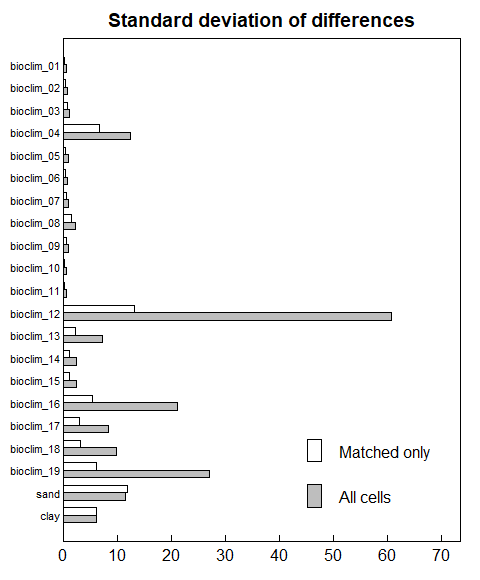

```r
# Bring the full subsetcells data in again to get all variables
data(subsetcells)

# Get all variables for Subset cells now:
subsetcells <- subsetcells[,c("site_ids","X_WGS84","Y_WGS84",
                              names(subsetcells)[8:28])]
rownames(subsetcells) <- subsetcells$site_ids

# Convert sand and clay fraction to percentage in subsetcells
subsetcells$sand <- subsetcells$sand*100
subsetcells$clay <- subsetcells$clay*100

# Run evaluateMatching
sddiffs <- evaluateMatching(allvars = allvars,
                            subsetcells = subsetcells,
                            matches = quals2, secondarymatch = TRUE,
                            quality_name = "matching_quality",
                            matchingvars_id = "cellnumbers",
                            subsetcells_id = "site_ids",
                            subset_in_target = FALSE, matching_distance = 1.5,
                            plot_diffs = TRUE)
```

### Explanation of `evaluateMatching` outputs

A data frame of the standard deviation of differences between **target** and matched **subset cells** for all variables supplied in `allvars` data frame. The first row corresponds to the standard deviation of differences between **target** and **subset cells** for all cells and the second row corresponds to the standard deviation of differences between **target** and **subset cells** for only those **target cells** with matching quality $\le$ `matching_distance`. Units are the same as the units for each variable in `allvars`.

### 3. Calculate geographic distances between matched cells

Importantly, the quality of matching will also depend on the extent to which spatio-temporal patterns are maintained between matched cells. Our methods do not explicitly incorporate geographic proximity. Thus, **target cells** may be matched to geographically distant **subset cells** and simulation output from **subset cells** that are geographically distant may be assigned to adjacent **target cells**.

Although these cells may be well matched using the **matching variables**, they may exhibit daily patterns (e.g., precipitation, soil moisture) that are much less similar than would be expected for adjacent cells. To estimate the extent to which spatio-temporal patterns may have been maintained during matching, two measures of distance can be calculated using the `evaluateGeoDist` function:

1. The distance between **target cells** and their matched **subset cells**
2. The average distance between the **subset cell** that is matched to a given **target cell** and the **subset cells** that are matched to the eight adjacent neighbors of that **target cell**.

### Explanation of `evaluateGeoDist` arguments

Please also refer to the `evaluateGeoDist` documentation.

- `matches` A data frame output from the `multivarmatch` function.
- `subsetcells` A data frame of **subset cells** with column names corresponding exactly to those in `matchingvars`. Note that in our case here, we just need one set of coordinates for **subset cells** (since coordinates are the same for each soil type for each site).
- `subsetcells_id` The name of the column that contains the unique identifiers for each **subset cell**. Note that these unique identifiers should be numbers, but they may be classified as characters. These should match the ‘subset_cell’ column in the `matches` data frame.
- `subset_in_target` A boolean indicating if the **subset cells** are taken from within the **target cells**.
- `exclude_poor_matches` A boolean indicating if **target cells** with poor matching quality (weighted Euclidean distance between **target** and matched **subset cell** is greater than `matching_distance`) should be excluded from calculations.
- `quality_name` Name of the column in the `matches` data frame that contains the matching quality variable to use to evaluate matching “matching_quality” or “matching_quality_secondary”.
- `matching_distance` The maximum allowable weighted Euclidean distance between **target** and **subset cells** such that the matched cells can be considered analogous. (Set to 1.5 as described in *Renne et al.*).
- `longlat` A boolean to pass to an internal function. Indicates if the coordinates are in longitude and latitude format for calculating distances between points. Default value is `TRUE` and coordinates must be provided in this format.
- `raster_template` This is one of the rasters used to define the **target cells** and it is used as a template for creating rasters of distances.
- `map_distances` A boolean indicating whether to plot a map of distances between **target** and matched **subset cells**.
- `map_neighbor_distances` A boolean indicating whether to plot a map of the average distance between the **subset cell** matched to each **target cell** and the **subset cells** matched to the eight adjacent neighbors of that cell.
- `which_distance` A character indicating that both measures of distance should be calculated. See description for other options.
- `saverasters` A boolean indicating if the rasters of distances should be saved to file.

```r
# Bring the full subsetcells data in again to get 'site_id' varibles
data(subsetcells)

# Reduce to unique cell locations
subsetcells <- subsetcells[!duplicated(subsetcells$site_id),]

# Get all variables for Subset cells now:
subsetcells <- subsetcells[,c("site_id","X_WGS84","Y_WGS84")]
rownames(subsetcells) <- subsetcells$site_ids


# Look at geographic distances
geodist <- evaluateGeoDist(matches = quals, subsetcells = subsetcells,
                           subsetcells_id = 'site_id',
                           subset_in_target = FALSE,
                           quality_name = "matching_quality",
                           exclude_poor_matches = TRUE,
                           matching_distance = 1.5,
                           longlat = TRUE,
                           raster_template = targetcells[[1]])
```

*Distance (km) between* **target** *and* *matched* **subset cells***.*

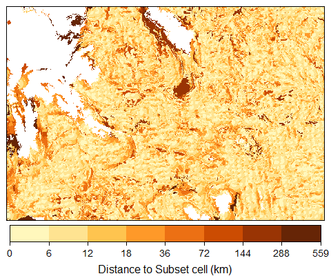

*Average distance between the* **subset cell** *that is matched to a given* **target cell** *and the* **subset cells** *that are matched to the eight adjacent neighbors of that* **target cell***.*

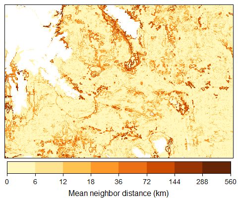

### Explanation of `evaluateGeoDist` outputs

Data frame with the distance between **target** and matched **subset cells** (‘target_to_subset_distance’) and the average distance between the **subset cell** matched to each **target cell** and the **subset cells** matched to the eight adjacent **target cells** (‘avgdistance_to_neighbors’). The first column and the rownames correspond to the unique identifiers for the **target cells**, and columns 2 and 3 correspond to the ‘x’ and ‘y’ coordinates of the **target cells**.

### 4. Leave-one-out cross-validation

Once simulations are complete for the **subset cells**, interpolation errors can calculated be estimated using leave-one-out cross validation (LOOCV) with the `loocv` function. In LOOCV, each **subset cell** is matched to its nearest neighbor from among the remaining **subset cells** (using Euclidean distance of the weighted **matching variables**). Then, an estimate of the interpolation error can be calculated using the following equation:

$$CVerror=\sqrt{\frac{1}k*∑_{i=1}^{k}(y_i-\hat y_i)^2}$$

Where $k$ is the number of **subset cells**, $y$ is the value of the simulated output variable, and $\hat y$ is the value of the matched output variable.

For our example here, we have simulation output generated by simulations used in Bradford et al. (2019).

```r
# Bring in subsetcells dataset again to get output variables
data(subsetcells)

# Create a mock dataset of output results
output_results <- subsetcells[,c("site_ids","Dryprop","CwetWinter","CdrySummer",
                                 "Cwet8","Dryall","Dryany")]
rownames(output_results) <- output_results$site_ids
```

### Explanation of `loocv` arguments

```r
# Get subsetcells
data(subsetcells)

# Pull out only matching variables and remove duplicates
matchingvars <- subsetcells[,c("site_id","X_WGS84","Y_WGS84","bioclim_01",
                         "bioclim_04","bioclim_09","bioclim_12",
                         "bioclim_15","bioclim_18")]

# Fix names
names(matchingvars) <- c("cellnumbers","x","y",names(matchingvars)[4:9])

# Remove duplicates (we will first match on climate only)
matchingvars <- matchingvars[!duplicated(matchingvars$cellnumbers),]
rownames(matchingvars) <- matchingvars$cellnumbers

# Remove cellnumbers column
matchingvars <- matchingvars[,-1]

# Pull out secondary vars and keep both identifiers
secondaryvars <- subsetcells[,c("site_id","X_WGS84","Y_WGS84","sand","clay")]

# Fix names
names(secondaryvars) <- c("cellnumbers","x","y",names(secondaryvars)[4:5])

# Convert sand and clay to percentage from fraction
secondaryvars$sand <- secondaryvars$sand*100
secondaryvars$clay <- secondaryvars$clay*100

# Remove duplicates
secondaryvars <- secondaryvars[!duplicated(secondaryvars$cellnumbers),]

# Set rownames as cellnumbers
rownames(secondaryvars) <- secondaryvars$cellnumbers

# Run leave-one-out cross validation of output results
loocv_results <- loocv(matchingvars = matchingvars,
                       secondaryvars = secondaryvars,
                       output_results = output_results,
                       criteria1 = criteria1, criteria2 = criteria2,
                       secondarymatch = TRUE,
                       secondaryvars_id = "cellnumbers",
                       reference_treatment = "1", n_neighbors = 2,
                       other_treatments = other_treatments)
```

### Explanation of `loocv` outputs

The output from the `loocv` function is a data frame of cross-validated matching, with coordinates (‘x’,‘y’) and cellnumber of each **subset cell** (‘target_cell’), unique id of matched non-self **subset cell** (‘subset_cell’) and matching quality (‘matching_quality’). Subsequent columns give the difference between simulated output values and the matched output values for each cell.

The `loocv` function output can be used to visualize the distribution of the matching errors.

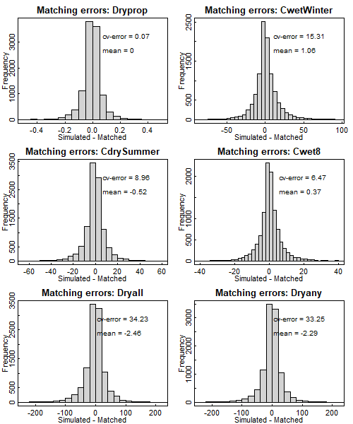

### Calculate matching errors

Finally, matching errors for each output variable can be estimated from the output of `loocv` using the `cverrors` function.

### Explanation of `cverrors` arguments

- `loocv_output` Output from `loocv` function.
- `first_output_column` The column number in the `loocv_output` data frame that corresponds to the first column of output variables (after the various columns that provide information on matching).

```r
# Estimate matching errors for each output variable
est_errors <- cverrors(loocv_output = loocv_results,
                       first_output_column = 8)
```

```
    Dryprop  CwetWinter  CdrySummer       Cwet8      Dryall      Dryany
 0.06741354 15.30992769  8.95753887  6.47243053 34.22868551 33.24872744
```

## Interpolate output variables

Finally, the `iterpolatePoints` function can be used to interpolate results from simulated **subset cells** to all **target cells** across the study area by assigning simulation results from the **subset cells** to their matched **target cells**.

For our example here, we will again use our set of output results from Bradford et al. (2019).

### Explanation of `interpolatePoints` arguments

Please also refer to the `interpolatePoints` documentation.

- `matches` A data frame output from the `multivarmatch` function.
- `output_results` A data frame containing simulation output results for all simulated sites (**subset cells**). The first column and the rownames should correspond to the unique identifiers for the **subset cells**. Importantly, these identifiers need to match the identifiers in the ‘subset_cell’ column of the `matches` data frame.
- `exclude_poor_matches` A boolean indicating if **target cells** with poor matching quality (weighted Euclidean distance between **target** and matched **subset cell** is greater than `matching_distance`) should be excluded from calculations.
- `subset_cell_names` The name of the column in the ‘matches’ data frame that contains the unique identifiers for the **subset cells** matched to each **target cell**.
- `quality_name` The name of the column in the ‘matches’ data frame that contains the matching quality for the **subset cells** matched to each **target cell**.
- `matching_distance` The maximum allowable weighted Euclidean distance between **target** and **subset cells** such that the matched cells can be considered analogous. (Set to 1.5 as described in Renne et al.).
- `raster_template` This is one of the rasters used to define the **target cells** and it is used as a template for creating interpolated output variables.
- `plotraster` A boolean indicating if a raster of matching quality should be plotted. (Defaults to `TRUE`).
- `overwrite` A boolean indicating if the `raster::writeRaster` function is allowed to overwrite existing files. (Defaults to `FALSE`).

```r
# Interpolate simulation output to rasters
interpolatePoints(matches = quals2, output_results = output_results,
                  exclude_poor_matches = TRUE,
                  subset_cell_names = "subset_cell_secondary",
                  quality_name = "matching_quality",
                  matching_distance = 1.5, raster_template = targetcells[[1]],
                  plotraster = TRUE, overwrite = FALSE)
```

*Interpolated output of DryPROP.*

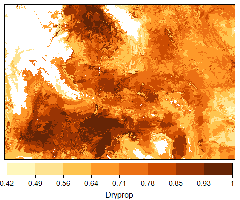

*Interpolated output of CwetWinter.*

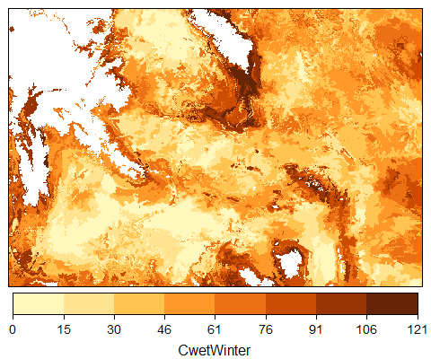

*Interpolated output of CdrySummer.*

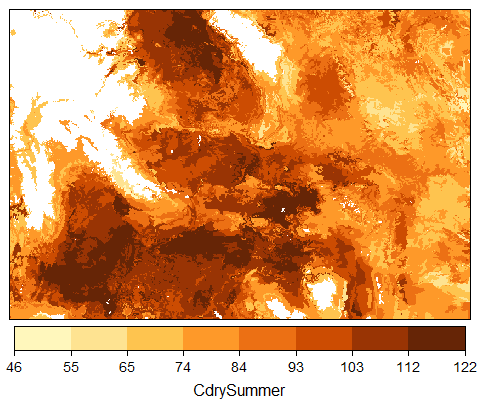

*Interpolated output of Cwet8.*

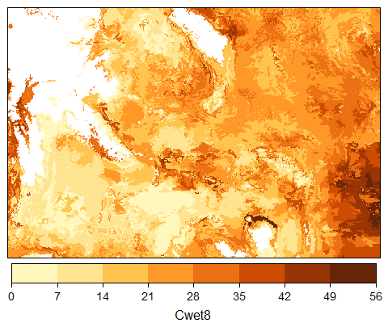

*Interpolated output of Dryall.*

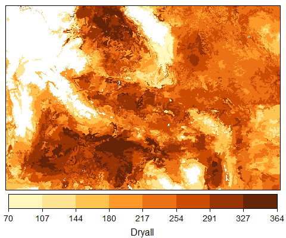

*Interpolated output of Dryany.*

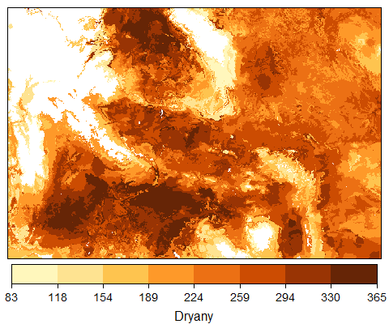

## References

Bradford, J. B., Schlaepfer, D. R., Lauenroth, W. K., Palmquist, K. A., Chambers, J. C., Maestas, J. D., & Campbell, S. B. (2019). Climate-driven shifts in soil temperature and moisture regimes suggest opportunities to enhance assessments of dryland resilience and resistance. *Front. Ecol. Evol*. 7:358. https://doi.org/10.3389/fevo.2019.00358

Hijmans, R. J. (2021). raster: Geographic Data Analysis and Modeling. R package version 3.4-13. https://CRAN.R-project.org/package=raster

Schlaepfer, D. R., Lauenroth, W. K., & Bradford, J. B. (2012). Ecohydrological niche of sagebrush ecosystems. *Ecohydrology* 5: 453-466. https://doi.org/10.1002/eco.238

Schlaepfer, D. R., & Andrews, C. A. (2018). rSFSW2: Simulation Framework for SOILWAT2. R package version 3.0.0.

Schlaepfer, D. R., & Murphy, R. (2018). rSOILWAT2: An Ecohydrological Ecosystem-Scale Water Balance Simulation Model. R package version 2.3.2.

Savje, F. (2019). distances: Tools for Distance Metrics. R package version 0.1.8. https://CRAN.R-project.org/package=distances